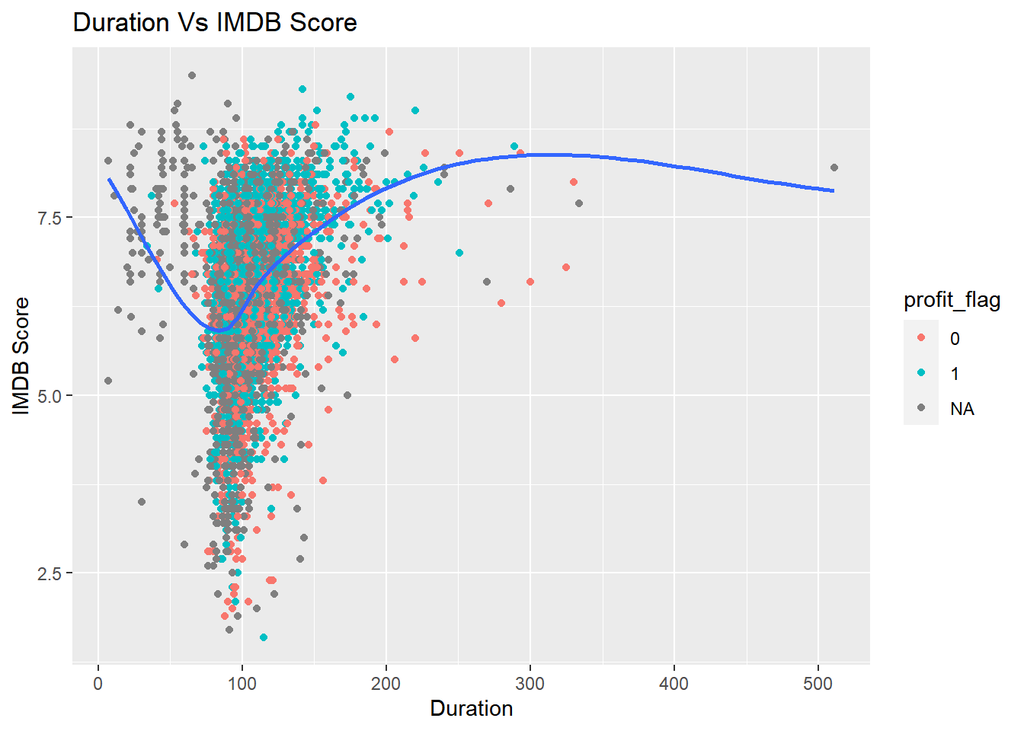

```r
ggplot(data, aes(x = duration, y = imdb_score))+
  geom_point(aes(color = profit_flag))+
  geom_smooth(method="loess", se=F) +
  labs(title="Duration Vs IMDB Score",
       x="Duration",
       y="IMDB Score",
       alt = "Scatterplot showing relationship between movie duration and IMDB score with trend line to see how the score changes")
```

Next, we wanted to see how gross revenue is distributed in this data set. From the density plot below, we can see that the revenue average for not profitable movies is less than that of profitable movies which is to be expected. Also, the profitable movies are more evenly spread in gross compared to not profitable movies.

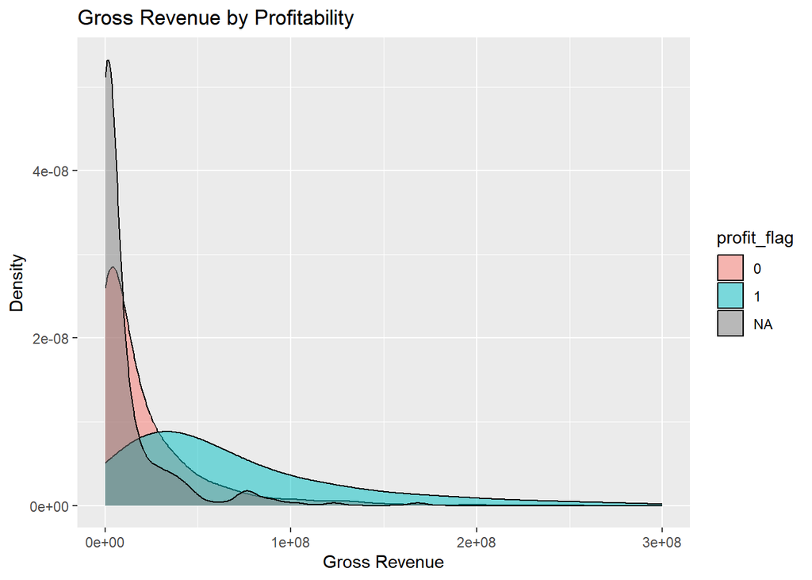

```r
ggplot(data, aes(x = gross, fill = profit_flag)) +
  geom_density(
    adjust = 2,
    alpha = 0.5) +
  xlim(0, 300000000)+
  labs(
    x = "Gross Revenue",
    y = "Density",
    title = "Gross Revenue by Profitability",
    alt = "Density plot of gross revenue and if it is profitable showing the wide spread of profitable movies")
```

Data Model:

The next thing that we wanted to do in our analysis was to create a model that could predict IMDB score based on the different variables in our data set. Based on the Corrgram below we created a model.

[figure not shown]

```r
require(corrgram)
corrgram(data, order=TRUE)
```

We decided to split the training and test data set into a 70-30 split. We used linear regression on the training data set to create our model object.

```r
dt = sort(sample(nrow(data), nrow(data)*.7))
train<-data[dt,]
test<-data[-dt,]
dim(train)
```

```
## [1] 3441   31
```

```r
lmModel <- lm(imdb_score ~ duration+gross+title_year, data = train)

# Printing the model object
print(lmModel)
```

```
##
## Call:
## lm(formula = imdb_score ~ duration + gross + title_year, data = train)
##
## Coefficients:
## (Intercept)     duration        gross   title_year
##   2.029e+01    1.341e-02    2.164e-09   -7.681e-03
```

```r
summary(lmModel)
```

```
##
## Call:
## lm(formula = imdb_score ~ duration + gross + title_year, data = train)
##
## Residuals:
##     Min      1Q  Median      3Q     Max
## -4.9444 -0.5507  0.0971  0.6942  2.3696
##
## Coefficients:
##               Estimate Std. Error t value Pr(>|t|)
## (Intercept)  2.029e+01  3.830e+00   5.298 1.26e-07 ***
## duration     1.341e-02  8.465e-04  15.839  < 2e-16 ***
## gross        2.164e-09  2.744e-10   7.885 4.46e-15 ***
## title_year  -7.681e-03  1.905e-03  -4.033 5.66e-05 ***
## ---
## Signif. codes:  0 '***' 0.001 '**' 0.01 '*' 0.05 '.' 0.1 ' ' 1
##
## Residual standard error: 0.9793 on 2816 degrees of freedom
##   (621 observations deleted due to missingness)
## Multiple R-squared:  0.1357, Adjusted R-squared:  0.1347
## F-statistic: 147.3 on 3 and 2816 DF,  p-value: < 2.2e-16
```

This combination of variables wasn’t creating a very accurate model so we tried including more categorical variables.

The new model included categorical variables and we checked for variables with p-values lower than 0.05.

```r
new_lmModel <- lm(imdb_score ~ gross + budget  + title_year  +num_voted_users+ num_critic_for_reviews + duration + profit_flag, data = train)
# Printing the model object
print(new_lmModel)
```

```
##
## Call:
## lm(formula = imdb_score ~ gross + budget + title_year + num_voted_users +
##     num_critic_for_reviews + duration + profit_flag, data = train)
##
## Coefficients:
##            (Intercept)                   gross                  budget
##              3.185e+01              -1.919e-09              -3.398e-09
##             title_year         num_voted_users  num_critic_for_reviews
##             -1.344e-02               2.772e-06               1.951e-03
##               duration            profit_flag1
##              9.940e-03               1.387e-01
```

```r
summary(new_lmModel)
```

```
##
## Call:
## lm(formula = imdb_score ~ gross + budget + title_year + num_voted_users +
##     num_critic_for_reviews + duration + profit_flag, data = train)
##
## Residuals:
##     Min      1Q  Median      3Q     Max
## -4.6938 -0.4444  0.0800  0.5643  3.3625
##
## Coefficients:
##                          Estimate Std. Error t value Pr(>|t|)
## (Intercept)             3.185e+01  4.083e+00   7.801 8.78e-15 ***
## gross                  -1.919e-09  4.006e-10  -4.790 1.76e-06 ***
## budget                 -3.398e-09  4.923e-10  -6.901 6.45e-12 ***
## title_year             -1.344e-02  2.033e-03  -6.612 4.58e-11 ***
## num_voted_users         2.772e-06  1.782e-07  15.557  < 2e-16 ***
## num_critic_for_reviews  1.951e-03  2.049e-04   9.518  < 2e-16 ***
## duration                9.940e-03  8.150e-04  12.196  < 2e-16 ***
## profit_flag1            1.387e-01  4.078e-02   3.402  0.00068 ***
## ---
## Signif. codes:  0 '***' 0.001 '**' 0.01 '*' 0.05 '.' 0.1 ' ' 1
##
## Residual standard error: 0.8698 on 2618 degrees of freedom
##   (815 observations deleted due to missingness)
## Multiple R-squared:  0.3288, Adjusted R-squared:  0.327
## F-statistic: 183.2 on 7 and 2618 DF,  p-value: < 2.2e-16
```

This model has a better R-squared value which makes this more accurate. The Residuals plot below shows us the difference between the observed and the fitted model points. As we can see a pattern in the residual plot, this indicates that a linear model might not be ideal in this situation.

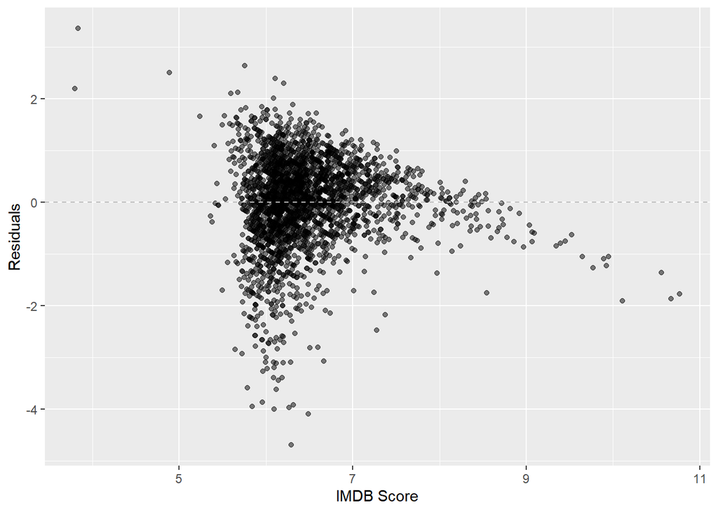

```r
ggplot(new_lmModel, mapping = aes(x = .fitted, y = .resid)) +
  geom_point(alpha = 0.5) +
  geom_hline(yintercept = 0, color = "gray", lty = "dashed") +
  labs(x = "IMDB Score", y = "Residuals")
```

When we compare the predicted values, they are not very accurate but are pretty close.

```r
head(test$imdb_score)
```

```
## [1] 7.1 8.5 6.2 7.5 7.3 6.7
```

```r
head(predict(new_lmModel, test))
```

```
##        2        4        7       10       14       19
## 6.980873 9.630271 6.873481 6.707333 7.014504 6.767569
```

Overall, we found that this data set doesn’t contain all the information required for us to create the most accurate prediction of IMDB score. We need a more vast data set and other variables to be able to predict IMDB Score.